# Multi Role

- Introduction
- Hardware Prerequisites
- Software Prerequisites
- Assumptions/Considerations
- Usage
  - Advertise
  - Discover Devices
  - Connect
  - GATT Read
  - GATT Write
  - Connection Update
  - Disconnect

## Introduction

The `multi_role` project demonstrates the capabilities of the Texas Instruments BLE stack to function in multiple simultaneous connection roles.

Specifically, the project is capable of functioning as a master and a slave simultaneously, in any combination, while maintaining up to the amount of connections defined by `MAX_NUM_BLE_CONNS`. Check on this preprocessor define for the default value.

The project is capable of connecting to any central/peripheral device. Any type of legacy pairing/bonding is possible. Parameter updates are supported. Connections can be established in any role. The project supports multiple simultaneous GATT discoveries and/or pairings/bondings.

This project has the following app configurations available:

| App Build Configuration | Description |
| --- | --- |
| FlashROM_Release (default) | All TI-RTOS debug features disabled but application-logging to UART remains enabled. The application uses the config file `ble_release.cfg` and the defines are in `<app name>_FlashROM_Release.opt`. |
| FlashROM_Debug | All TI-RTOS debug features enabled. The application uses the config file `ble_debug.cfg` and the defines are in `<app name>_FlashROM_Debug.opt`. |

All application configurations use the stack library configuration, FlashROM_Library. This build configuration will yield additional flash footprint optimizations by the linker since the application and stack can share contiguous flash pages. This configuration is further discussed in the Stack Library Configuration section of the **BLE5-Stack User’s Guide** provided in the SDK.

## Hardware Prerequisites

The default Multi Role board configuration uses the device’s LaunchPad development kit. This hardware configuration is shown in the below image:

[figure not shown]

For custom hardware, see the Running the SDK on Custom Boards section of the **BLE5-Stack User’s Guide**.

## Software Prerequisites

For information on what versions of Code Composer Studio and IAR Embedded Workbench to use, see the Release Notes file provided in the SDK. For information on how to import this project into your IDE workspace and build/run, please refer to the device’s Platform section in the **BLE5-Stack User’s Guide**.

## Assumptions/Considerations

In this document, the terms master/central and slave/peripheral are used synonymously. It is assumed that the master/central devices are GATT clients and slave/peripheral devices are GATT servers. Once the connection limit (set with the `MAX_NUM_BLE_CONNS` preprocessor define) is reached, the `multi_role` device won’t be allowed to advertise/scan until there is a disconnection.

When connected in the master role, the `multi_role` device will query the slave device for the simpleGATTProfile service in order to demo some basic GATT procedures (read/write characteristic). However, it is not necessary for the slave device to contain this service in order for a connection to be established. That is, it is possible for the peripheral devices in the system to have differing attribute tables since the `multi_role` device will perform a service/characteristic discovery after each connection is formed.

By default, the `multi_role` application is configured to filter and connect to peripheral devices with the TI Simple Profile UUID, such as devices with the `simple_peripheral` project. To modify this behavior, set `DEFAULT_DEV_DISC_BY_SVC_UUID` to `FALSE` in `multi_role.c`.

If the project is configured for too many connections (via the `MAX_NUM_BLE_CONNS` preprocessor define) and also security, it is possible for heap allocation failures to occur which will break the stack. Therefore, the project should be stress-tested for its intended use case to verify that there are no heap issues by including the `HEAPMGR_METRICS` preprocessor define. See the Debugging section of the **BLE5-Stack User’s Guide** for more information on how to do this.

When at least one connection is already formed, in order to allow enough processing time to scan for a new connection, the minimum possible connection interval (in milliseconds) that can be used is:

`12.5 + 5*n`

## Usage

The `multi_role` project uses the two buttons on the LaunchPad to accept user input and outputs information through the UART. This application uses the UART peripheral to provide an interface for the application. The UART is only used for display messages. This document will use a terminal program (Tera Term, PuTTY, etc.) to serve as the display for the output of the LaunchPad. Note that any other serial terminal can be used. The following default parameters are used for the UART peripheral for display:

| UART Param | Default Values |
| --- | --- |
| Baud Rate | 115200 |
| Data length | 8 bits |
| Parity | None |
| Stop bits | 1 bit |
| Flow Control | None |

Upon powering on or resetting the device, the user will see the main menu. When in the main menu, the left button will scroll through the possible actions, which are:

- Discover Devices
- Advertise

Other options will become available once devices are scanned, and again once a connection is formed.

The device will report upon startup that it is initialized, advertising, and connected to 0 devices:

[figure not shown]

The right button is used to select one of the available options. Each option will be covered in the following sections.

### Advertise

Selecting this option will toggle advertising on and off. It will display “Adv Set 0 Disabled” when advertising is off and “Adv Set 0 Enabled” when advertising is on. By default, advertising is on which will send out connectable advertisements from the device.

### Discover Devices

Selecting this option will start a device discovery to search for advertising devices. It will then display the number of devices found:

[figure not shown]

### Connect

After selecting `Discover Devices`, the option to connect to a device will now become available. Selecting the `+Connect` option to allow you to scroll through the discovered devices:

[figure not shown]

A device can then be selected to initiate a connection. The connect option can be chosen again to connect with additional peripheral devices. The terminal window will display the number of devices that are connected to the Multi Role device. With a device now connected, select `+Work with` and select the appropriate connected device.

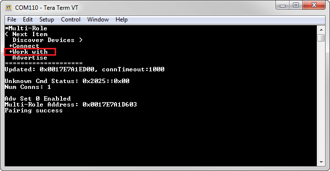

At this point, the following options are present to be selected:

- GATT Read
- GATT Write
- Connection Update
- Disconnect

It is also possible to select “Upper Menu” to return to the main menu.

### GATT Read

This option is used to send read requests to the peripheral device. Pressing the right button once will send a read request to the connected device and will print the returned value of the characteristic. Note that this characteristic can be written to with the `GATT Write` option:

[figure not shown]

### GATT Write

This option is used to write predetermined values (0x00, 0x55, 0xAA, etc.) to the device’s characteristic. Note that this characteristic can be read from with the `GATT Read` option:

[figure not shown]

### Connection Update

This option updates the connection parameters based on the values set by the following constants in `multi_role.c`:

- DEFAULT_UPDATE_MIN_CONN_INTERVAL
- DEFAULT_UPDATE_MAX_CONN_INTERVAL
- DEFAULT_UPDATE_SLAVE_LATENCY
- DEFAULT_UPDATE_CONN_TIMEOUT

The update was successful if it states that it has been “Updated” and displays the new connection timeout value.

[figure not shown]

### Disconnect

This option will send a link termination request to terminate the connection with the connected device. The following shows a successful disconnection:

[figure not shown]